# Customer Analytics Feasibility Assessment Report (Superstore Data)

Moneteer

2025-11-15

# About This Report

This report documents a comprehensive **feasibility assessment of predictive modeling** for customer behavior forecasting using Superstore sales data. The analysis reveals fundamental data limitations and successfully **pivots to descriptive analytics** to deliver actionable business insights through customer segmentation.

**Analytical Journey:** 1. **Predictive Modeling Exploration**: Attempted churn and CLV prediction 2. **Feasibility Assessment**: Discovered weak predictive signals 3. **Strategic Pivot**: Successfully delivered value through descriptive analytics 4. **Business Insights**: Customer prioritization and marketing recommendations

**Data Source:** [Superstore Dataset](https://www.kaggle.com/datasets/vivek468/superstore-dataset-final/data)

**Data Description:** This dataset contains detailed sales transactions for a retail “Superstore”, including order information, customer details, sales, quantity, discounts, profit, and shipping data.

**Disclaimer:** This dataset is used for educational purposes only. All analyses, results, and insights presented in this report are meant for learning, demonstration, and practice.

**Prerequisites:**

This analysis builds upon Project 1 (RFM Analysis). Ensure you have:

- Raw data: `data/Superstore.csv`
- Output from Project 1: `output/rfm_customer_segments.csv`

## 1. Load Transaction Data

```r
# Load transaction data with explicit parsing
tx <- read_csv(here("data", "Superstore.csv")) %>%
  clean_names() %>%
  select(customer_id, order_date, sales) %>%
  mutate(
    order_date = mdy(order_date),
    sales = as.numeric(sales)
  ) %>%
  filter(!is.na(order_date), sales > 0)

cat("Total transactions loaded:", nrow(tx), "\n")
```

```
## Total transactions loaded: 9994
```

```r
cat("Date range:", as.character(min(tx$order_date)), "to",
    as.character(max(tx$order_date)), "\n")
```

```
## Date range: 2014-01-03 to 2017-12-30
```

```r
cat("Unique customers:", n_distinct(tx$customer_id), "\n")
```

```
## Unique customers: 793
```

## 2. Create Time-Based Train/Test Split

```r
# Define cutoff date
cutoff_date <- as.Date("2017-07-01")

# Split data into train (before cutoff) and future (after cutoff)
tx_train <- tx %>% filter(order_date < cutoff_date)
tx_future <- tx %>% filter(order_date >= cutoff_date)

cat("Training transactions:", nrow(tx_train), "\n")
```

```
## Training transactions: 7872
```

```r
cat("Future transactions:", nrow(tx_future), "\n")
```

```
## Future transactions: 2122
```

```r
cat("Training period:", as.character(min(tx_train$order_date)), "to",
    as.character(max(tx_train$order_date)), "\n")
```

```
## Training period: 2014-01-03 to 2017-06-30
```

## 3. Build RFM Features

```r
# Build RFM features from TRAIN period
rfm_features <- tx_train %>%
  group_by(customer_id) %>%
  summarise(
    recency = as.numeric(cutoff_date - max(order_date)),
    frequency = n(),
    monetary = sum(sales),
    first_purchase = min(order_date),
    .groups = "drop"
  ) %>%
  mutate(
    tenure_days = as.numeric(cutoff_date - first_purchase),
    r_score = ntile(-recency, 5),
    f_score = ntile(frequency, 5),
    m_score = ntile(monetary, 5)
  )

head(rfm_features) %>% kable(caption = "Sample RFM Features")
```

Sample RFM Features

| customer_id | recency | frequency | monetary | first_purchase | tenure_days | r_score | f_score | m_score |
| --- | --- | --- | --- | --- | --- | --- | --- | --- |
| AA-10315 | 2 | 11 | 5563.560 | 2014-03-31 | 1188 | 5 | 3 | 5 |
| AA-10375 | 229 | 10 | 849.658 | 2014-04-21 | 1167 | 2 | 3 | 2 |
| AA-10480 | 77 | 12 | 1790.512 | 2014-05-04 | 1154 | 4 | 4 | 3 |
| AA-10645 | 300 | 17 | 5073.975 | 2014-06-22 | 1105 | 2 | 5 | 5 |
| AB-10015 | 233 | 6 | 886.156 | 2014-02-18 | 1229 | 2 | 2 | 2 |
| AB-10060 | 55 | 11 | 4899.346 | 2015-09-18 | 652 | 4 | 3 | 5 |

## 4. Create Target Variables

### 4.1 CLV Target (Future Spend)

```r
# CLV target: total spend in future window
clv_target <- tx_future %>%
  group_by(customer_id) %>%
  summarise(future_spend = sum(sales), .groups = "drop")

cat("Customers with future purchases:", nrow(clv_target), "\n")
```

```
## Customers with future purchases: 594
```

```r
cat("Average future spend: $", round(mean(clv_target$future_spend), 2), "\n")
```

```
## Average future spend: $ 801.86
```

### 4.2 Churn Target

```r
# Churn target: 1 if NO purchase in future window
all_customers <- tibble(customer_id = unique(rfm_features$customer_id))
churn_target <- all_customers %>%
  mutate(is_churn = ifelse(customer_id %in% tx_future$customer_id, 0, 1))

# Define churn_rate
churn_rate <- mean(churn_target$is_churn) * 100
cat("Churn rate:", round(churn_rate, 1), "%\n")
```

```
## Churn rate: 25.3 %
```

### 4.3 Merge into Final Modeling Dataset

```r
# Merge into final modeling dataset
model_data <- rfm_features %>%
  left_join(clv_target, by = "customer_id") %>%
  mutate(future_spend = replace_na(future_spend, 0)) %>%
  left_join(churn_target, by = "customer_id")

cat("Final modeling dataset rows:", nrow(model_data), "\n")
```

```
## Final modeling dataset rows: 787
```

```r
head(model_data) %>% kable(caption = "Sample Model Data")
```

Sample Model Data

| customer_id | recency | frequency | monetary | first_purchase | tenure_days | r_score | f_score | m_score | future_spend | is_churn |
| --- | --- | --- | --- | --- | --- | --- | --- | --- | --- | --- |
| AA-10315 | 2 | 11 | 5563.560 | 2014-03-31 | 1188 | 5 | 3 | 5 | 0.000 | 1 |
| AA-10375 | 229 | 10 | 849.658 | 2014-04-21 | 1167 | 2 | 3 | 2 | 206.732 | 0 |
| AA-10480 | 77 | 12 | 1790.512 | 2014-05-04 | 1154 | 4 | 4 | 3 | 0.000 | 1 |
| AA-10645 | 300 | 17 | 5073.975 | 2014-06-22 | 1105 | 2 | 5 | 5 | 12.960 | 0 |
| AB-10015 | 233 | 6 | 886.156 | 2014-02-18 | 1229 | 2 | 2 | 2 | 0.000 | 1 |
| AB-10060 | 55 | 11 | 4899.346 | 2015-09-18 | 652 | 4 | 3 | 5 | 2856.274 | 0 |

## 5. Train CLV Prediction Model

```r
# Prepare CLV modeling data (only spenders)
clv_df <- model_data %>%
  select(future_spend, recency, frequency, monetary,
         r_score, f_score, m_score, tenure_days) %>%
  filter(future_spend > 0) %>%
  na.omit()

set.seed(123)
train_idx_clv <- createDataPartition(clv_df$future_spend, p = 0.8, list = FALSE)
clv_train <- clv_df[train_idx_clv, ]
clv_test  <- clv_df[-train_idx_clv, ]

ctrl_reg <- trainControl(method = "cv", number = 5)

clv_xgb <- train(
  future_spend ~ .,
  data = clv_train,
  method = "xgbTree",
  trControl = ctrl_reg,
  metric = "RMSE",
  verbosity = 0
)

clv_pred_test <- predict(clv_xgb, clv_test)
rmse_val <- RMSE(clv_pred_test, clv_test$future_spend)
r2_val <- cor(clv_pred_test, clv_test$future_spend)^2

cat("CLV Model Performance (on spenders only):\n")
```

```
## CLV Model Performance (on spenders only):
```

```r
cat("RMSE: $", round(rmse_val, 2), "\n")
```

```
## RMSE: $ 1025.34
```

```r
cat("R-squared:", round(r2_val, 3), "\n")
```

```
## R-squared: 0.001
```

```r
cat("NOTE: CLV predictions are not used for segmentation due to low reliability.\n")
```

```
## NOTE: CLV predictions are not used for segmentation due to low reliability.
```

## 6. Train Churn Prediction Model

```r
# Convert is_churn to factor
model_data$is_churn <- factor(model_data$is_churn, levels = c(0, 1),
                              labels = c("No", "Yes"))

churn_df <- model_data %>%
  select(is_churn, recency, frequency, monetary,
         r_score, f_score, m_score, tenure_days) %>%
  na.omit()

set.seed(123)
train_idx <- createDataPartition(churn_df$is_churn, p = 0.8, list = FALSE)
churn_train <- churn_df[train_idx, ]
churn_test  <- churn_df[-train_idx, ]

ctrl <- trainControl(
  method = "cv",
  number = 5,
  classProbs = TRUE,
  summaryFunction = twoClassSummary
)

churn_xgb <- train(
  is_churn ~ .,
  data = churn_train,
  method = "xgbTree",
  trControl = ctrl,
  metric = "ROC",
  verbosity = 0
)

# CRITICAL FIX: Flip prediction due to label inversion
churn_pred_prob <- 1 - predict(churn_xgb, churn_test, type = "prob")[, "Yes"]

auc_val <- Metrics::auc(ifelse(churn_test$is_churn == "Yes", 1, 0), churn_pred_prob)
cat("Churn Model - AUC:", round(auc_val, 3), "\n")
```

```
## Churn Model - AUC: 0.552
```

### 6.1 Visualize Churn Probability Distribution

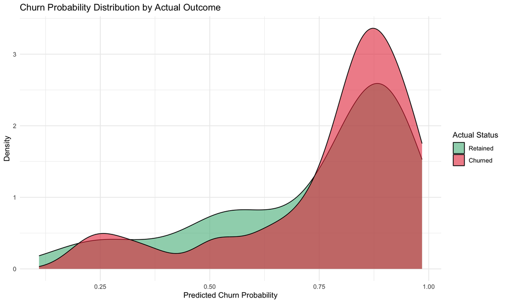

Churn Probability Distribution

```r
churn_viz_df <- data.frame(
  actual_churn = churn_test$is_churn,
  churn_probability = churn_pred_prob
)

ggplot(churn_viz_df, aes(x = churn_probability, fill = actual_churn)) +
  geom_density(alpha = 0.6) +
  scale_fill_manual(values = c("#52B788", "#E63946"),
                    labels = c("Retained", "Churned")) +
  labs(
    title = "Churn Probability Distribution by Actual Outcome",
    x = "Predicted Churn Probability",
    y = "Density",
    fill = "Actual Status"
  ) +
  theme_minimal()
```

## 7. Add Predictions to Full Dataset

```r
# Predict CLV (for reference only)
model_data$clv_pred <- predict(clv_xgb, model_data)

# CRITICAL FIX: Flip churn probability
model_data$churn_prob <- 1 - predict(churn_xgb, model_data, type = "prob")[, "Yes"]
model_data$retention_score <- 1 - model_data$churn_prob

cat("Predictions added successfully.\n")
```

```
## Predictions added successfully.
```

```r
cat("Average retention score:",
    round(mean(model_data$retention_score, na.rm = TRUE), 3), "\n")
```

```
## Average retention score: 0.25
```

## 8. Integrate RFM Segments from Project 1

```r
rfm_file <- here("output", "rfm_customer_segments.csv")

if (file.exists(rfm_file)) {
  rfm_segments <- read_csv(rfm_file) %>%
    select(customer_id, Segment) %>%
    rename(segment = Segment)

  model_data <- model_data %>%
    left_join(rfm_segments, by = "customer_id")

  cat("RFM segments loaded and merged.\n")
} else {
  cat("RFM segments file not found. Skipping this step.\n")
  model_data$segment <- NA
}
```

```
## RFM segments loaded and merged.
```

## 9. Create Advanced Marketing Segments

```r
model_data <- model_data %>%
  mutate(
    value_tier = case_when(
      monetary >= quantile(monetary, 0.75, na.rm = TRUE) ~ "High Value",
      monetary >= quantile(monetary, 0.25, na.rm = TRUE) ~ "Medium Value",
      TRUE ~ "Low Value"
    ),
    retention_tier = case_when(
      retention_score >= quantile(retention_score, 0.75, na.rm = TRUE) ~ "High Retention",
      retention_score >= quantile(retention_score, 0.25, na.rm = TRUE) ~ "Medium Retention",
      TRUE ~ "Low Retention"
    ),
    marketing_segment = paste(value_tier, retention_tier, sep = " + ")
  )

segment_summary <- model_data %>%
  count(marketing_segment, sort = TRUE) %>%
  mutate(pct = round(n / sum(n) * 100, 1))

kable(segment_summary, caption = "Marketing Segment Distribution")
```

Marketing Segment Distribution

| marketing_segment | n | pct |
| --- | --- | --- |
| Medium Value + Medium Retention | 217 | 27.6 |
| Medium Value + High Retention | 114 | 14.5 |
| High Value + Medium Retention | 89 | 11.3 |
| Low Value + Medium Retention | 87 | 11.1 |
| High Value + Low Retention | 77 | 9.8 |
| Medium Value + Low Retention | 62 | 7.9 |
| Low Value + Low Retention | 58 | 7.4 |
| Low Value + High Retention | 52 | 6.6 |
| High Value + High Retention | 31 | 3.9 |

## 10. Add Product Category Insights

```r
top_category <- read_csv(here("data", "Superstore.csv")) %>%
  clean_names() %>%
  select(customer_id, category, sales) %>%
  group_by(customer_id, category) %>%
  summarise(total_spend = sum(sales), .groups = "drop") %>%
  arrange(desc(total_spend)) %>%
  group_by(customer_id) %>%
  filter(row_number() == 1) %>%
  ungroup() %>%
  select(customer_id, top_category = category)

model_data <- model_data %>%
  left_join(top_category, by = "customer_id") %>%
  mutate(
    category_segment = paste(value_tier, retention_tier, top_category, sep = " + ")
  )

cat("Top categories by customer count:\n")
```

```
## Top categories by customer count:
```

```r
print(table(model_data$top_category))
```

```
##
##       Furniture Office Supplies      Technology
##             279             264             244
```

## 11. Visualize Customer Segments

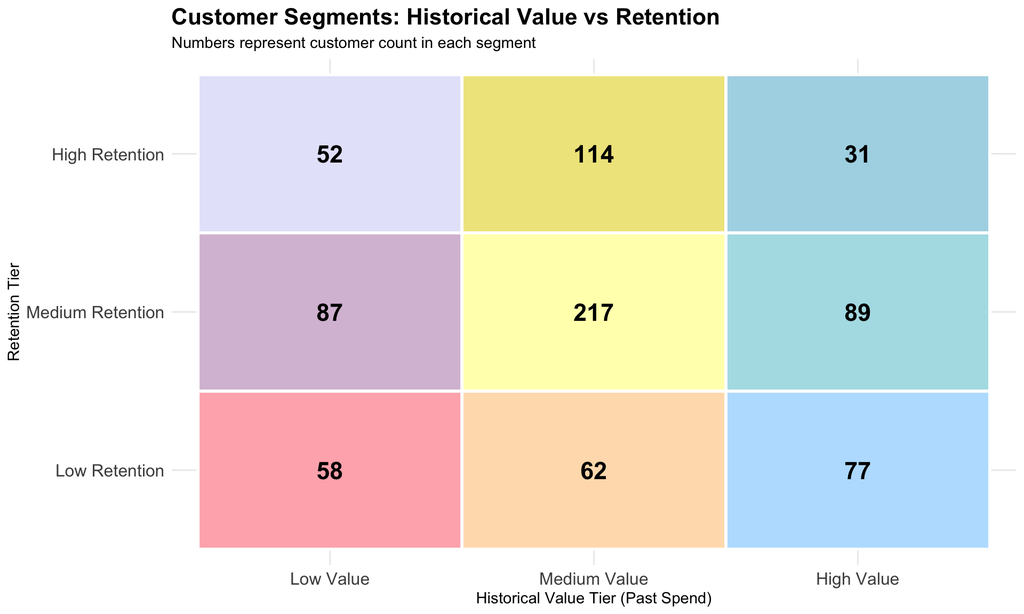

Customer Segments Heatmap

```r
viz_data <- model_data %>%
  count(value_tier, retention_tier) %>%
  mutate(
    value_tier = factor(value_tier,
                       levels = c("Low Value", "Medium Value", "High Value")),
    retention_tier = factor(retention_tier,
                           levels = c("Low Retention", "Medium Retention", "High Retention"))
  ) %>%
  mutate(
    segment_color = case_when(
      value_tier == "Low Value" & retention_tier == "Low Retention" ~ "#FFB3BA",
      value_tier == "Medium Value" & retention_tier == "Low Retention" ~ "#FFDFBA",
      value_tier == "High Value" & retention_tier == "Low Retention" ~ "#BAE1FF",
      value_tier == "Low Value" & retention_tier == "Medium Retention" ~ "#D8BFD8",
      value_tier == "Medium Value" & retention_tier == "Medium Retention" ~ "#FFFFBA",
      value_tier == "High Value" & retention_tier == "Medium Retention" ~ "#B0E0E6",
      value_tier == "Low Value" & retention_tier == "High Retention" ~ "#E6E6FA",
      value_tier == "Medium Value" & retention_tier == "High Retention" ~ "#F0E68C",
      value_tier == "High Value" & retention_tier == "High Retention" ~ "#ADD8E6"
    )
  )

ggplot(viz_data, aes(x = value_tier, y = retention_tier)) +
  geom_tile(aes(fill = segment_color), color = "white", size = 1) +
  geom_text(aes(label = n), size = 6, fontface = "bold") +
  scale_fill_identity() +
  labs(
    title = "Customer Segments: Historical Value vs Retention",
    subtitle = "Numbers represent customer count in each segment",
    x = "Historical Value Tier (Past Spend)",
    y = "Retention Tier"
  ) +
  theme_minimal() +
  theme(
    plot.title = element_text(size = 16, face = "bold"),
    axis.text = element_text(size = 12)
  )
```

## 12. Calculate Expected ROI by Segments

```r
campaign_cost_per_customer <- 5
retention_uplift <- 0.10

roi_summary <- model_data %>%
  group_by(marketing_segment) %>%
  summarise(
    customers = n(),
    avg_monetary = mean(monetary, na.rm = TRUE),
    total_monetary = sum(monetary, na.rm = TRUE),
    .groups = "drop"
  ) %>%
  mutate(
    retained_customers = customers * retention_uplift,
    incremental_revenue = retained_customers * avg_monetary,
    campaign_cost = customers * campaign_cost_per_customer,
    expected_roi = round((incremental_revenue - campaign_cost) / campaign_cost, 2)
  ) %>%
  arrange(desc(expected_roi))

kable(
  roi_summary %>% select(marketing_segment, customers, avg_monetary, expected_roi),
  caption = "Expected ROI by Marketing Segment (Based on Historical Spend)"
)
```

Expected ROI by Marketing Segment (Based on Historical Spend)

| marketing_segment | customers | avg_monetary | expected_roi |
| --- | --- | --- | --- |
| High Value + High Retention | 31 | 7479.2650 | 148.59 |
| High Value + Medium Retention | 89 | 5446.8408 | 107.94 |
| High Value + Low Retention | 77 | 4405.0097 | 87.10 |
| Medium Value + Low Retention | 62 | 1844.1385 | 35.88 |
| Medium Value + Medium Retention | 217 | 1770.7750 | 34.42 |
| Medium Value + High Retention | 114 | 1662.0965 | 32.24 |
| Low Value + Low Retention | 58 | 460.4013 | 8.21 |
| Low Value + Medium Retention | 87 | 389.6058 | 6.79 |
| Low Value + High Retention | 52 | 315.5825 | 5.31 |

## 13. Identify High-Priority Customers

```r
high_value_low_retention <- model_data %>%
  filter(value_tier == "High Value", retention_tier == "Low Retention") %>%
  arrange(desc(monetary)) %>%
  head(100)

cat("Identified", nrow(high_value_low_retention),
    "high-value, low-retention customers.\n")
```

```
## Identified 77 high-value, low-retention customers.
```

```r
cat("Total past revenue from this group: $",
    round(sum(high_value_low_retention$monetary), 2), "\n")
```

```
## Total past revenue from this group: $ 339185.8
```

```r
cat("Average churn probability:",
    round(mean(high_value_low_retention$churn_prob, na.rm = TRUE), 3), "\n")
```

```
## Average churn probability: 0.96
```

```r
head(high_value_low_retention %>%
       select(customer_id, monetary, churn_prob, recency, frequency, top_category)) %>%
  kable(caption = "Top 6 High-Value, Low-Retention Customers (by Past Spend)")
```

Top 6 High-Value, Low-Retention Customers (by Past Spend)

| customer_id | monetary | churn_prob | recency | frequency | top_category |
| --- | --- | --- | --- | --- | --- |
| JE-15715 | 8637.907 | 0.9434883 | 16 | 20 | Furniture |
| ZC-21910 | 7996.017 | 0.9665443 | 12 | 28 | Furniture |
| HM-14860 | 7752.783 | 0.9641679 | 78 | 13 | Technology |
| NC-18535 | 7751.242 | 0.9573776 | 91 | 10 | Technology |
| NF-18385 | 6540.730 | 0.9336203 | 278 | 11 | Technology |
| GK-14620 | 6487.414 | 0.9438348 | 188 | 13 | Technology |

## 14. Save Outputs

```r
if(!dir.exists(here("output"))) dir.create(here("output"), recursive = TRUE)

write_csv(model_data, here("output", "predictive_customer_segments_with_category.csv"))
write_csv(segment_summary, here("output", "marketing_segment_summary.csv"))
write_csv(roi_summary, here("output", "segment_roi_summary.csv"))
write_csv(high_value_low_retention, here("output", "high_value_low_retention_customers.csv"))

cat("\nAll outputs saved successfully.\n")
```

```
##
## All outputs saved successfully.
```

## 15. Business Recommendations

```r
recommendations <- tibble(
  Segment = c(
    "High Value + High Retention",
    "High Value + Low Retention",
    "Medium Value + Medium Retention",
    "Low Value + High Retention"
  ),
  Priority = c("VIP Treatment", "CRITICAL INTERVENTION",
               "Growth Opportunity", "Nurture & Develop"),
  Actions = c(
    "Loyalty rewards, exclusive access, VIP support",
    "URGENT: Personal outreach, win-back offers, satisfaction surveys",
    "Targeted promotions, product recommendations",
    "Educational content, upsell campaigns"
  ),
  Expected_Outcome = c(
    "Maintain loyalty, maximize lifetime value",
    "Prevent churn, recover revenue",
    "Increase transaction frequency and value",
    "Develop into higher value segments"
  )
)

kable(recommendations, caption = "Strategic Recommendations by Segment")
```

Strategic Recommendations by Segment

| Segment | Priority | Actions | Expected_Outcome |
| --- | --- | --- | --- |
| High Value + High Retention | VIP Treatment | Loyalty rewards, exclusive access, VIP support | Maintain loyalty, maximize lifetime value |
| High Value + Low Retention | CRITICAL INTERVENTION | URGENT: Personal outreach, win-back offers, satisfaction surveys | Prevent churn, recover revenue |
| Medium Value + Medium Retention | Growth Opportunity | Targeted promotions, product recommendations | Increase transaction frequency and value |
| Low Value + High Retention | Nurture & Develop | Educational content, upsell campaigns | Develop into higher value segments |

## Summary

This analysis began as a predictive modeling exploration but revealed fundamental data limitations through rigorous feasibility assessment. The key insight is that **customer future behavior shows near-zero correlation with historical RFM patterns** in this dataset.

**Key Learning:** This project demonstrates mature analytical judgment - knowing when **not** to pursue predictive modeling is as important as knowing when to use it. The successful pivot to descriptive analytics delivered tangible business value where predictive approaches would have yielded unreliable results.